# Final twitter mining

# Twitter mining of Taylor Swift

# Set up twitter

```r
#api_key <-     "GSy0OnHP4gyzzGDmg4z4sBZWJ"
#api_secret <- "zJmaXWGhADHYjLnTh5tj7xvP2ScxYOMN0cUE1jivpnhrHtOYXZ"
#access_token <- "777970685280944128-HD4tfrqhv4oT1WkHCNiYu1kJmJ4L33Z"
#access_token_secret <- "fQEQlk5ySwUZKABmHMARLXlwM2aDoqKZPsQdK3Okx5SS8"

#setup_twitter_oauth(api_key, api_secret, access_token, access_token_secret)

#library(ROAuth)
#requestURL <- "https://api.twitter.com/oauth/request_token"
#accessURL <- "https://api.twitter.com/oauth/access_token"
#authURL <- "https://api.twitter.com/oauth/authorize"
#consumerKey <- "GSy0OnHP4gyzzGDmg4z4sBZWJ"
#consumerSecret <- "zJmaXWGhADHYjLnTh5tj7xvP2ScxYOMN0cUE1jivpnhrHtOYXZ"
#my_oauth <- OAuthFactory$new(consumerKey = consumerKey, consumerSecret = consumerSecret, requestURL = requestURL, accessURL = accessURL, authURL = authURL)
#my_oauth$handshake(cainfo = system.file("CurlSSL", "cacert.pem", package = "RCurl"))
#save(my_oauth, file = "my_oauth.Rdata")
```

# Text mining and get twitter of Taylor Swift

```r
#1 get data searchtwitter/streamin
#TS<-searchTwitter("Taylor Swift", n=800, lang="en",since="2016-08-20")
#TS.df <- twListToDF(TS)
#write.csv(TS.df,file = "TS.csv")
TS.df<-read.csv("TS.csv")
TS_text= sapply(TS.df$text,function(row) iconv(row, "latin1", "ASCII", sub=""))
```

# clean text

```r
# remove retweet entities
TS_text = gsub('(RT|via)((?:\\b\\W*@\\w+)+)', '', TS_text)
# remove at people
TS_text = gsub('@\\w+', '', TS_text)
# remove punctuation
TS_text = gsub('[[:punct:]]', '', TS_text)
# remove numbers
TS_text = gsub('[[:digit:]]', '', TS_text)
# remove html links
TS_text = gsub('http\\w+', '', TS_text)
# remove unnecessary spaces
TS_text = gsub('[ \t]{2,}', '', TS_text)
TS_text = gsub('^\\s+|\\s+$', '', TS_text)
```

# Analysis text word cloud

[figure not shown]

```r
TS_corpus = Corpus(VectorSource(TS_text))
#clean the data
tdm = TermDocumentMatrix(
  TS_corpus,
  control = list(
    stopwords = c("taylor", "swift","instagram","just","now","taylorswift","billboard","swifts","ever","actually","http","can",stopwords("english")),
    tolower = TRUE))
m = as.matrix(tdm)

# get word counts in decreasing order
word_freqs = sort(rowSums(m), decreasing = TRUE)
# create a data frame with words and their frequencies
dm = data.frame(word = names(word_freqs), freq = word_freqs)

wordcloud(dm$word, dm$freq, random.order = FALSE, min.freq=5,colors = brewer.pal(8, "Dark2"))
```

# sentiment analysis

### sentiment analysis by hand

```r
library(stringr)

sample1<-sample(TS.df$text,20,replace = FALSE)
sample1<-data.frame(sample1)
sample2<-sample(TS.df$text,20,replace = FALSE)
sample2<-data.frame(sample2)
sample3<-sample(TS.df$text,20,replace = FALSE)
sample3<-data.frame(sample3)

# After sample these tweets I can find positive and negative words
positivew<-c("queen","fans","favorite","love","good","top","best","like","famous")
negativew<-c("fuck","hate","fucking","negative","hell","shit","damn","sucks","awful")

# sentiment score function
score.sentiment = function(sentences, pos.words, neg.words, .progress='none')
{
    require(plyr)
    require(stringr)

    scores = laply(sentences, function(sentence, pos.words, neg.words) {

        sentence = gsub('[[:punct:]]', '', sentence)
        sentence = gsub('[[:cntrl:]]', '', sentence)
        sentence = gsub('\\d+', '', sentence)
        sentence = tolower(sentence)

        word.list = str_split(sentence, '\\s+')
        words = unlist(word.list)

        # compare our words to the dictionaries of positive & negative terms
        pos.matches = match(words, pos.words)
        neg.matches = match(words, neg.words)

        # match() returns the position of the matched term or NA
        # we just want a TRUE/FALSE:
        pos.matches = !is.na(pos.matches)
        neg.matches = !is.na(neg.matches)

        score = sum(pos.matches) - sum(neg.matches)

        return(score)
    }, pos.words, neg.words, .progress=.progress )

    scores.df = data.frame(score=scores, text=sentences)
    return(scores.df)
}

a<-score.sentiment(TS_text,positivew,negativew)
```

# permutation test

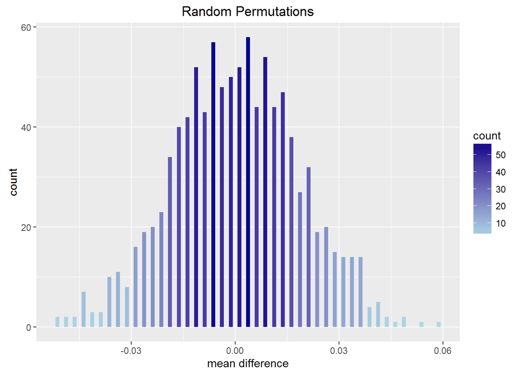

```r
# research sample
#TS1<-searchTwitter("Taylor Swift", n=800, lang="en",since="2016-08-20")
#TS1.df <- twListToDF(TS1)
#write.csv(TS1.df,"TS1.csv")
TS1.df<-read.csv("TS1.csv")
TS_text1= sapply(TS1.df$text,function(row) iconv(row, "latin1", "ASCII", sub=""))

b<-score.sentiment(TS_text1,positivew,negativew)
write.csv("a","a.csv")
write.csv("b","b.csv")
test.diff<-mean(a$score)-mean(b$score)

l1<-length(a$score)
l2<-length(b$score)
lt<-l1+l2

data <- c(a$score, b$score)

it <- function(n){
  M = NULL
  for(i in 1:n){
    s = sample(data, lt, FALSE)
    m1 = mean(s[1:l1]) - mean(s[(l1+1):lt])
    M = c(M,m1)
  }
  return(M)
}

diff <- it(1000)
diff<-data.frame(diff)
ggplot(diff,aes(x=diff))+geom_bar(aes(fill=..count..))+scale_fill_continuous(low="lightblue",high="darkblue")+ggtitle("Random Permutations")+xlab("mean difference")
```

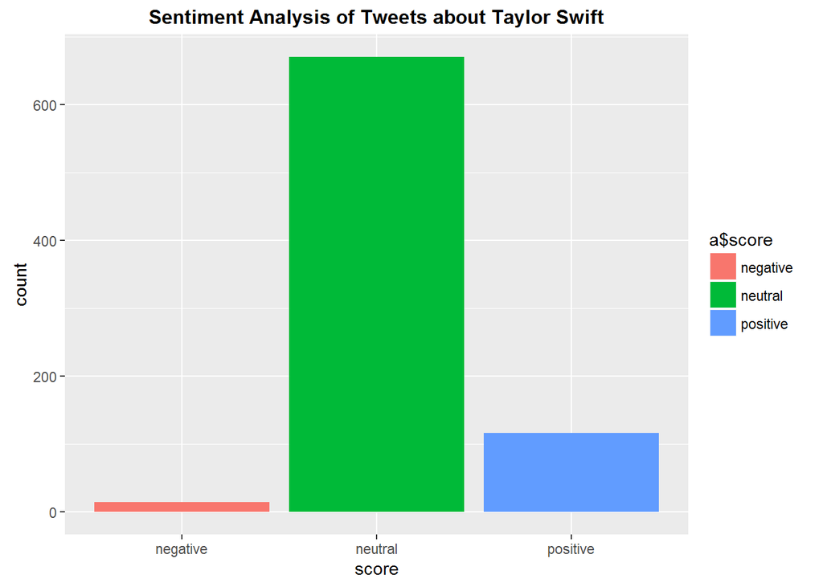

```r
a$score[which(a$score>0)]<-"positive"
a$score[which(a$score<0)]<-"negative"
a$score[which(a$score==0)]<-"neutral"

ggplot(a,aes(x=score))+geom_bar(aes(y=..count.., fill=a$score))+
  theme(plot.title = element_text(size=12, face='bold'))+
  ggtitle('Sentiment Analysis of Tweets about Taylor Swift')
```

### sentiment analysis by sentiment package

According to the plot, it seems that most people like Taylor Swift, there are less neutral scores ,probably this package has much more positive words than I do with my sentiment score function

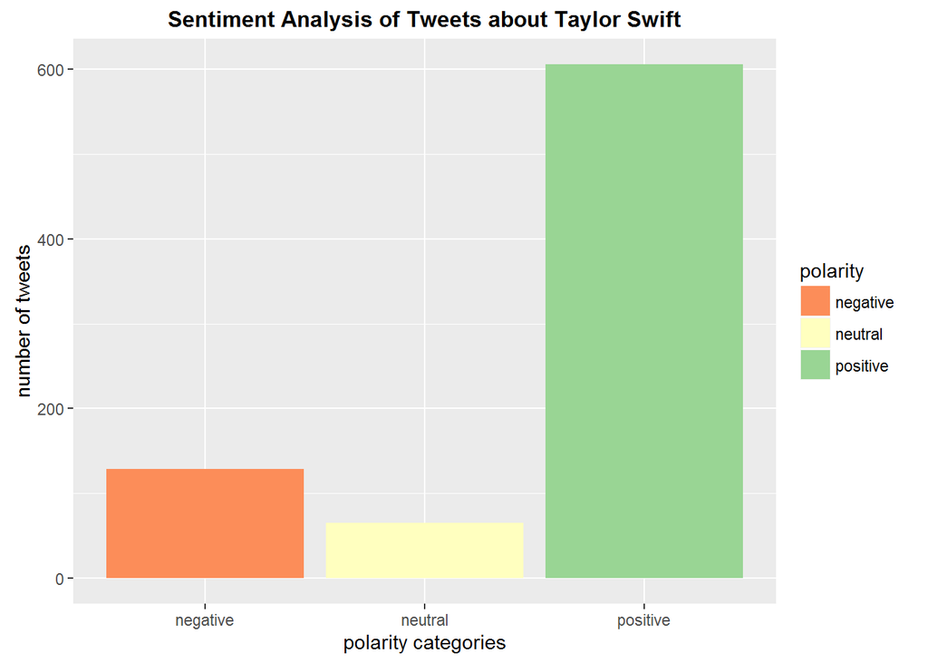

```r
class_pol =sentiment::classify_polarity(TS_text, algorithm='bayes')
polarity = class_pol[,4]
sent_df = data.frame(text=TS_text,
polarity=polarity, stringsAsFactors=FALSE)

#plot
q<-ggplot(sent_df, aes(x=polarity)) +
geom_bar(aes(y=..count.., fill=polarity)) +
scale_fill_brewer(palette='Spectral') +
labs(x='polarity categories', y='number of tweets') +
ggtitle('Sentiment Analysis of Tweets about Taylor Swift') +
theme(plot.title = element_text(size=12, face='bold'))
q
```

# map about twitter user

This graph shows that people send tweets about Taylor Swift in different locations of America, if the twitt is more favorited, the color is darker.

```r
#twitter user location
#filterStream("TSS1.json",
 #track=c("taylor swift"),
 #            locations=c(-125,25,-66,50),
  #           language = "en",
  #           timeout=150, oauth=my_oauth)
#TSS1.df <- parseTweets("TSS1.json", verbose=FALSE)
#write.csv(TSS1.df,"TSS1.csv")
TSS1.df<-read.csv("TSS1.csv")

TSpoints<-data.frame(x=as.numeric(TSS1.df$lon),y=as.numeric(TSS1.df$lat),z=as.numeric(TSS1.df$favourites_count))
TSpoints<-na.omit(TSpoints)

map.data <- map_data("state")
TSpoints <- TSpoints[TSpoints$y>25,]
TSpoints$z<-TSpoints$z+1
summary(TSpoints)
```

```
##        x                 y               z
##  Min.   :-123.81   Min.   :25.08   Min.   :     1.0
##  1st Qu.: -99.14   1st Qu.:33.83   1st Qu.:     1.0
##  Median : -86.06   Median :38.89   Median :     2.0
##  Mean   : -91.65   Mean   :37.62   Mean   :  1625.8
##  3rd Qu.: -78.23   3rd Qu.:41.51   3rd Qu.:   227.2
##  Max.   : -70.22   Max.   :49.90   Max.   :199996.0
```

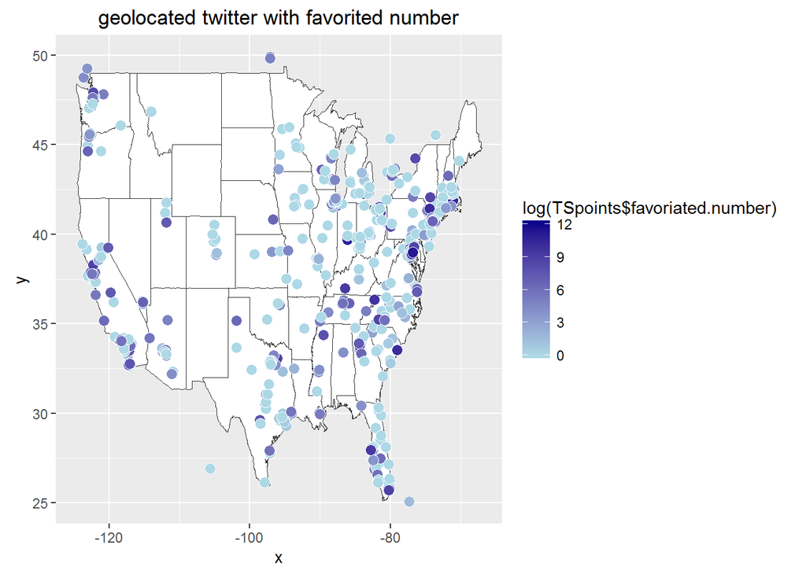

```r
names(TSpoints)<-c("x","y","favoriated.number")
ggplot(map.data)+
  geom_map(aes(map_id=region),
           map=map.data,
           fill="white",
           color="grey20",size=0.25)+
  expand_limits(x=map.data$long,y=map.data$lat)+ geom_jitter(data=TSpoints,
                                                            aes(x=x,y=y,fill=log(TSpoints$favoriated.number)),size=3,shape=21,color="white")+scale_fill_continuous(low = "lightblue", high = "darkblue", guide="colorbar")+ggtitle("geolocated twitter with favorited number")
```

```r
                                                                      #color=ifelse(TSpoints$z>0,TSpoints$z[which(TSpoints$z>0)],"grey"))
```

# Sentiment analysis in different state

After calculating the number of twitter in each state, I Plot state map, in each picture, darker the color is , larger the number or the proportion is. The plots can show people’s general attitude towards Taylor Swift in different state

```r
#clean twitter
TSmap<-TSS1.df %>% filter(country=="United States"&place_type=="city")
# get state name
substrRight <- function(x, n){
  substr(x, nchar(x)-n+1, nchar(x))
}
TSmap$full_name<-as.character(TSmap$full_name)
TSmap$full_name<-substrRight(TSmap$full_name,2)
TS.n<-tally(group_by(TSmap,full_name))

TS_text1= sapply(TSmap$text,function(row) iconv(row, "latin1", "ASCII", sub=""))

#sentiment analysis
SA=sentiment::classify_polarity(TS_text1, algorithm='bayes')
SA<-data.frame(SA)
polarityS= SA[,4]
TSmapS<-cbind(TSmap,polarityS)
#Calculate positive, negative, and neutral number of tweets in different state
#Positive number
stateP<-TSmapS%>% filter(TSmapS$polarityS=="positive")
stateP<-tally(group_by(stateP,full_name))
#Negative number
stateN<-TSmapS%>% filter(TSmapS$polarityS=="negative")
stateN<-tally(group_by(stateN,full_name))
#Neutral number
stateO<-TSmapS%>% filter(TSmapS$polarityS=="neutral")
stateO<-tally(group_by(stateO,full_name))

TS.n<-tally(group_by(TSmap,full_name))
TS.n<-join(TS.n,stateO,by="full_name")
TS.n<-join(TS.n,stateN,by="full_name")
TS.n<-join(TS.n,stateP,by="full_name")
names(TS.n)<-c("region","total.num","neu.num","neg.num","pos.num")
TS.n[which(TS.n==NA),]<-0

# get full state name
TS.n$region<-state.name[match(TS.n$region, state.abb)]
TS.n$region<-tolower(TS.n$region)


allstate=map_data("state")
allstate<-join(allstate,TS.n,by="region")

allstate$pos.prop<-allstate$pos.num/allstate$total.num
allstate$neu.prop<-allstate$neu.num/allstate$total.num
allstate$neg.prop<-allstate$neg.num/allstate$total.num

allstate[which(allstate$.==NA),]<-0

write.csv(allstate,"allstate.csv")
```

Total number of Twitter plot

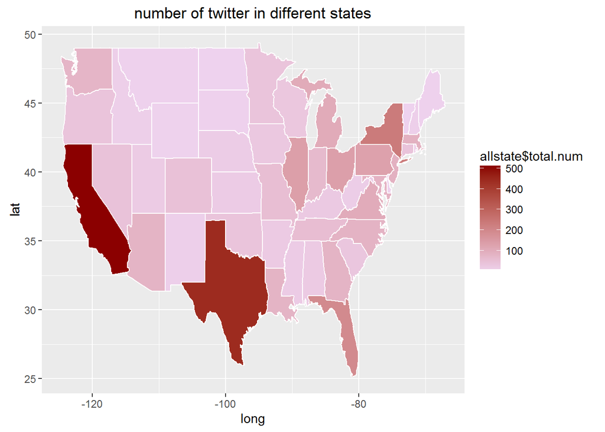

```r
# plot maps
p <- ggplot()
p <- p + geom_polygon(data=allstate, aes(x=long, y=lat, group = group, fill=allstate$total.num),colour="white")+ scale_fill_continuous(low = "thistle2", high = "darkred", guide="colorbar")+ggtitle("number of twitter in different states")
p
```

positive proportion of Twitter plot

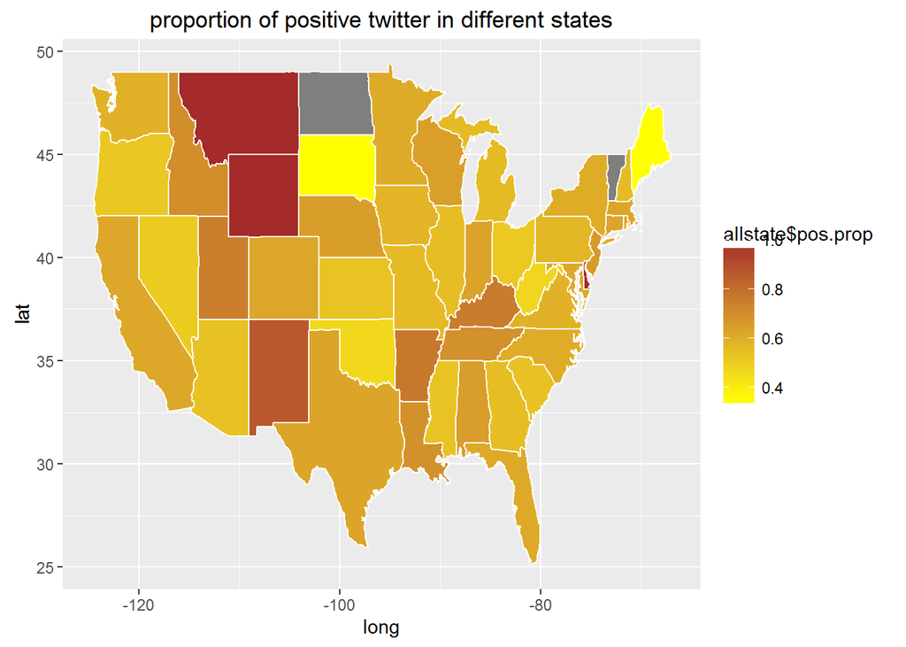

```r
pos<- ggplot()
pos <- pos + geom_polygon(data=allstate, aes(x=long, y=lat, group = group, fill=allstate$pos.prop),colour="white")+ scale_fill_continuous(low = "yellow", high = "brown", guide="colorbar")+ggtitle("proportion of positive twitter in different states")
pos
```

negative proportion of Twitter plot

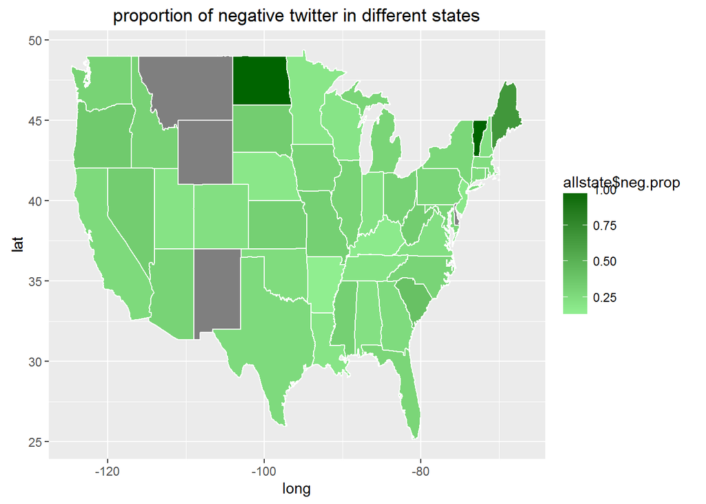

```r
neg<- ggplot()
neg<- neg + geom_polygon(data=allstate, aes(x=long, y=lat, group = group, fill=allstate$neg.prop),colour="white")+ scale_fill_continuous(low = "lightgreen", high = "darkgreen", guide="colorbar")+ggtitle("proportion of negative twitter in different states")
neg
```